# Tuto3 : Régression logistique

```r
library(tidyverse)
theme_set(theme_classic(base_size=12))
```

## Exercice 1 (Modèle logistique simple)

Un chef d’entreprise souhaite vérifier la qualité de ces machines en fonction de l’âge et de la marque des moteurs. Il dispose

- d’une variable binaire **etat** (1 si le moteur a déjà connu une panne, 0 sinon) ;
- d’une variable quantitative **age** repésentant l’âge du moteur ;
- d’une variable qualitative a 3 modalités **marque** représentant la marque du moteur.

Les données se trouvent dans le fichier *panne.txt*.

1. Importer le jeu de données et, si cela est nécessaire, transformer les variables qualitatives en facteur (on pourra utiliser la commande **as.factor**).

```r
donnees <- read.table("panne.txt",header=T)
summary(donnees)
```

```
##       etat             age         marque
##  Min.   :0.0000   Min.   : 1.000   A:11
##  1st Qu.:0.0000   1st Qu.: 2.000   B:15
##  Median :1.0000   Median : 5.000   C: 7
##  Mean   :0.5152   Mean   : 5.364
##  3rd Qu.:1.0000   3rd Qu.: 7.000
##  Max.   :1.0000   Max.   :16.000
```

```r
donnees$etat <- as.factor(donnees$etat)
summary(donnees)
```

```
##  etat        age         marque
##  0:16   Min.   : 1.000   A:11
##  1:17   1st Qu.: 2.000   B:15
##         Median : 5.000   C: 7
##         Mean   : 5.364
##         3rd Qu.: 7.000
##         Max.   :16.000
```

2. Ecrire le modèle logistique permettant d’expliquer la variable $Y$ par la variable **age** uniquement.

$$\text{logit } p(x)=\beta_0+\beta_1 x$$
où $p(x)=P(Y=1|X=x)$.

3. Ajuster ce modèle logistique sur *R* à l’aide de la fonction *glm*.

```r
model1 <- glm(etat~age,data=donnees,family=binomial)
summary(model1)
```

```
##
## Call:
## glm(formula = etat ~ age, family = binomial, data = donnees)
##
## Deviance Residuals:
##    Min      1Q  Median      3Q     Max
## -1.253  -1.199   1.015   1.183   1.210
##
## Coefficients:
##             Estimate Std. Error z value Pr(>|z|)
## (Intercept) -0.10748    0.59864  -0.180    0.858
## age          0.03141    0.09117   0.345    0.730
##
## (Dispersion parameter for binomial family taken to be 1)
##
##     Null deviance: 45.717  on 32  degrees of freedom
## Residual deviance: 45.598  on 31  degrees of freedom
## AIC: 49.598
##
## Number of Fisher Scoring iterations: 3
```

4. Quelle est la probabilité estimée par ce modèle qu’une machine d’un an et demi tombe en panne ? Même question pour une machine de 10 ans.

```r
b0 <- coef(model1)[1]
b1 <- coef(model1)[2]
x <- c(1.5,10)
prob <- exp(b0+b1*x)/(1+exp(b0+b1*x))
prob
```

```
## [1] 0.4849130 0.5514744
```

On peut retrouver ces résultats à l’aide de la fonction **predict** :

```r
new_df <- data.frame(age=c(1.5,10))
predict(model1,newdata=new_df,type="response")
```

```
##         1         2
## 0.4849130 0.5514744
```

5. Critiquer le modèle.

```r
summary(model1)
```

```
##
## Call:
## glm(formula = etat ~ age, family = binomial, data = donnees)
##
## Deviance Residuals:
##    Min      1Q  Median      3Q     Max
## -1.253  -1.199   1.015   1.183   1.210
##
## Coefficients:
##             Estimate Std. Error z value Pr(>|z|)
## (Intercept) -0.10748    0.59864  -0.180    0.858
## age          0.03141    0.09117   0.345    0.730
##
## (Dispersion parameter for binomial family taken to be 1)
##
##     Null deviance: 45.717  on 32  degrees of freedom
## Residual deviance: 45.598  on 31  degrees of freedom
## AIC: 49.598
##
## Number of Fisher Scoring iterations: 3
```

Ce modèle accepte la nullité de $\beta_1$ ce qui implique le modèle avec uniquement la constante est meilleur que le modèle construit.

6. On souhaite maintenant constuire le modèle logistique

$$\textrm{logit }p(\textrm{age})=\beta_0+\beta_1\textrm{age}+\beta_2\textrm{age}^2.$$
Expliquer quelles peuvent être les motivations pour envisager un tel modèle.

Améliorer le modèle en se disant que la variable **age** n’intervient peut-être pas linéairement.

7. Quelle est la probabilité estimée par ce modèle qu’une machine d’un an et demi tombe en panne ? Même question pour une machine de 10 ans.

```r
model2 <- glm(etat~age+I(age^2),data=donnees,family=binomial)
b0 <- coef(model2)[1]
b1 <- coef(model2)[2]
b2 <- coef(model2)[3]
x <- c(1.5,10)
prob2 <- exp(b0+b1*x+b2*x^2)/(1+exp(b0+b1*x+b2*x^2))
prob2
```

```
## [1] 0.8221353 0.8102202
```

Ou encore, toujours avec **predict**

```r
predict(model2,newdata=new_df,type="response")
```

```
##         1         2
## 0.8221353 0.8102202
```

8. Représenter l’allure de la fonction $p(\textrm{age})$ en fonction de l’age des machines. Conclure.

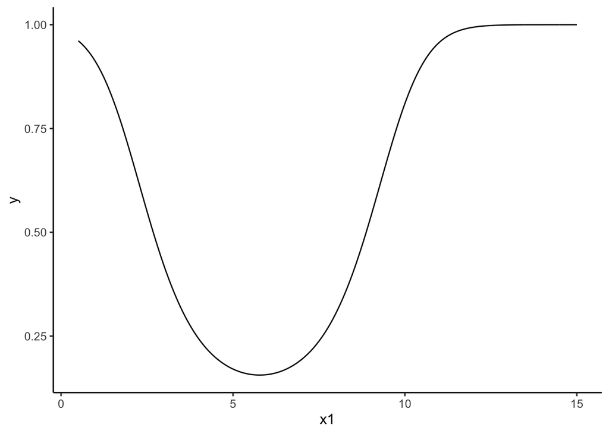

```r
x1 <- seq(0.5,15,by=0.01)
y <- exp(b0+b1*x1+b2*x1^2)/(1+exp(b0+b1*x1+b2*x1^2))
df <- data.frame(x=x1,y)
ggplot(df)+aes(x=x1,y=y)+geom_line()
```

La probabilité de panne est plus élevée pour les machines jeunes (rodage) et vieilles (usure). L’effet quadratique permet de prendre en compte ce fait.

Il est bien entendu difficile de savoir quels effets mettre dans le modèle. Les résidus partiels peuvent aider :

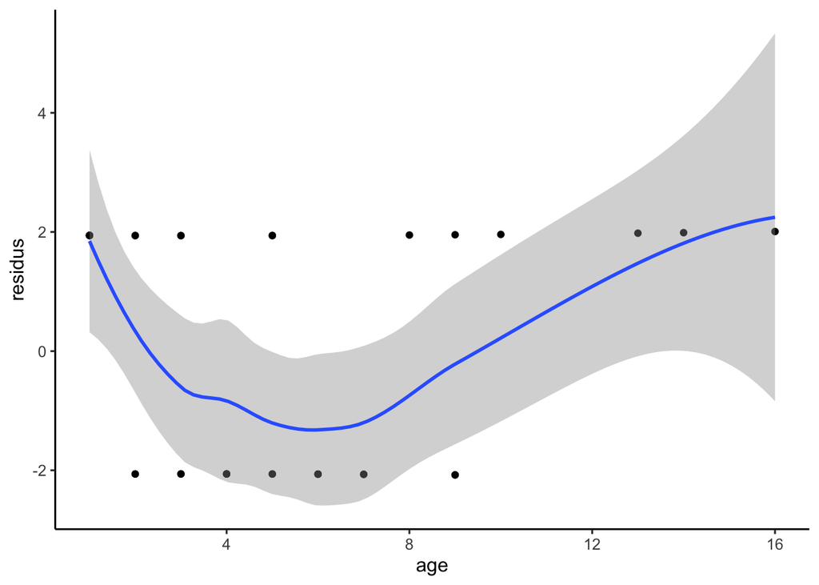

```r
residpartiel <- residuals(model1,type="partial")
df <- data.frame(age=donnees$age,residus=residpartiel[,"age"])
ggplot(df)+aes(x=age,y=residus)+geom_point()+geom_smooth()
```

## Exercice 2

On considère $X$ une variable aléatoire qualitative qui suit une loi uniforme de support $\{A,B,C\}$ et $Y$ une variable dichotomique telle que :
$$Y|X=A\sim\textrm{Ber}(0.95),\quad Y|X=B\sim\textrm{Ber}(0.95),\quad Y|X=C\sim\textrm{Ber}(0.05).$$

On peut générer un échantillon de taille 100 de ce modèle avec :

```r
set.seed(1234)
X <- sample(c("A","B","C"),100,replace=TRUE) %>% as.factor()
Y <- rep(0,100)
Y[X=="A"] <- rbinom(sum(X=="A"),1,0.95)
Y[X=="B"] <- rbinom(sum(X=="B"),1,0.95)
Y[X=="C"] <- rbinom(sum(X=="C"),1,0.05)
donnees <- data.frame(X,Y)
```

1. Expliquer la manière dont on peut prendre en compte une variable expliquative qualitative dans un modèle de régression logistique.

On code les modalités de la variable qualitative à l’aide d’indicatrices.

2. Construire le modèle 1 :
   $$\textrm{logit} p(x)=\beta_0+\beta_1\mathbf{1}_{x=A}+\beta_2\mathbf{1}_{x=B}+\beta_3\mathbf{1}_{x=C}$$
   muni de la contrainte $\beta_1=0$ (on pourra utiliser la fonction **glm**), puis
- Donner les estimations des paramètres.
- Faire un **summary** du modèle et analyser les sorties (on précisera notamment les tests effectués).

```r
model1 <- glm(Y~X,data=donnees,family=binomial)
summary(model1)
```

```
##
## Call:
## glm(formula = Y ~ X, family = binomial, data = donnees)
##
## Deviance Residuals:
##     Min       1Q   Median       3Q      Max
## -2.2761  -0.2561   0.3949   0.5448   2.6207
##
## Coefficients:
##             Estimate Std. Error z value Pr(>|z|)
## (Intercept)   1.8326     0.5385   3.403 0.000666 ***
## XB            0.6797     0.8064   0.843 0.399306
## XC           -5.2338     1.1504  -4.550 5.37e-06 ***
## ---
## Signif. codes:  0 '***' 0.001 '**' 0.01 '*' 0.05 '.' 0.1 ' ' 1
##
## (Dispersion parameter for binomial family taken to be 1)
##
##     Null deviance: 131.791  on 99  degrees of freedom
## Residual deviance:  53.415  on 97  degrees of freedom
## AIC: 59.415
##
## Number of Fisher Scoring iterations: 6
```

3. Construire le modèle 2 :
   $$\textrm{logit}\, p(x)=\beta_0+\beta_1\mathbf{1}_{x=A}+\beta_2\mathbf{1}_{x=B}+\beta_3\mathbf{1}_{x=C}$$
   muni de la contrainte $\beta_3=0$ (on pourra utiliser la fonction **glm** avec **C(X,base=3)**), puis
- donner les estimations des paramètres.
- faire un **summary** du modèle et analyser les sorties (on précisera notamment les tests effectués).

```r
model2 <- glm(Y~C(X,base=3),data=donnees,family=binomial)
summary(model2)
```

```
##
## Call:
## glm(formula = Y ~ C(X, base = 3), family = binomial, data = donnees)
##
## Deviance Residuals:
##     Min       1Q   Median       3Q      Max
## -2.2761  -0.2561   0.3949   0.5448   2.6207
##
## Coefficients:
##                 Estimate Std. Error z value Pr(>|z|)
## (Intercept)       -3.401      1.017  -3.346  0.00082 ***
## C(X, base = 3)1    5.234      1.150   4.550 5.37e-06 ***
## C(X, base = 3)2    5.914      1.181   5.009 5.47e-07 ***
## ---
## Signif. codes:  0 '***' 0.001 '**' 0.01 '*' 0.05 '.' 0.1 ' ' 1
##
## (Dispersion parameter for binomial family taken to be 1)
##
##     Null deviance: 131.791  on 99  degrees of freedom
## Residual deviance:  53.415  on 97  degrees of freedom
## AIC: 59.415
##
## Number of Fisher Scoring iterations: 6
```

4. Comparer les probabilités critiques du test $H_0 : \beta_2=0$ contre $H_1 : \beta_2\neq 0$ pour les deux modèles construits. Interpréter.

Le premier modèle accepte l’hypothèse nulle tandis que le second la rejette. Il faut donc prendre en compte la contrainte pour interpréter les paramètres (ne pas conclure quelque chose du genre *“la modalité $B$ est significative”*, cette phrase n’a pas de sens).

5. Proposer et mettre en oeuvre un test statistique permettant de répondre à la question : “Peut-on dire que $X$ à un effet sur $Y$ ?”

Il suffit de tester $H_0:\beta_1=\beta_2=\beta_3$, ce qui revient pour le premier modèle à tester $H_0:\beta_2=\beta_3=0$.

```r
model0<-glm(Y~1,data=donnees,family=binomial)
stat_2logL<-2*(logLik(model1)-logLik(model0))
1-pchisq(stat_2logL,df=length(coef(model1))-length(coef(model0)))
```

```
## 'log Lik.' 0 (df=3)
```

```r
library(car)
Anova(model1,type=3,test.statistic="Wald")
```

|  | Df | Chisq | Pr(>Chisq) |
| --- | --- | --- | --- |
| (Intercept) | 1 | 11.58053 | 6.664581e-04 |
| X | 2 | 26.38586 | 1.863734e-06 |

```r
Anova(model2,type=3,test.statistic="LR")
```

|  | LR Chisq | Df | Pr(>Chisq) |
| --- | --- | --- | --- |
| C(X, base = 3) | 78.376 | 2 | 9.569013e-18 |

## Exercice 3

On considère le jeu de données **SAheart** du package **bestglm**.

```r
library(bestglm)
data(SAheart)
```

1. Effectuer un test statistique permettant de comparer les modèles logistique expliquant **chd** par
- *sbp,tobacco,ldl* pour le premier modèle.
- *sbp,tobacco,ldl,obesity,alcohol,age* pour le second modèle.

```r
mod1 <- glm(chd~sbp+tobacco+ldl,data=SAheart,family=binomial)
mod2 <- glm(chd~sbp+tobacco+ldl+obesity+alcohol+age,data=SAheart,family=binomial)
anova(mod1,mod2,test="LRT")
```

|  | Resid. Df | Resid. Dev | Df | Deviance | Pr(>Chi) |
| --- | --- | --- | --- | --- | --- |
| 1 | 458 | 525.7416 | NA | NA | NA |
| 2 | 455 | 500.8851 | 3 | 24.8565 | 1.654481e-05 |

On rejette ici l’hypothèse nulle, on va donc privilégier le grand modèle.

2. Séparer l’échantillon en un échantillon d’apprentissage de taille 300 et un échantillon test de taille 162.

```r
donnees <- SAheart
set.seed(1234)
ind.app <- sample(nrow(donnees),300)
dapp <- donnees[ind.app,]
dtest <- donnees[-ind.app,]
```

3. A l’aide de l’échantillon d’apprentissage **uniquement**, sélectionner des variables en utilisant
- une procédure de recherche exhaustive pour les critères AIC et BIC ;
- une procédure pas à pas descendante pour le critère AIC.

Ajuster également un modèle d’analyse discriminante linéaire et quadratique.

```r
model.BIC <- bestglm(dapp,family=binomial,IC="BIC")
model.AIC <- bestglm(dapp,family=binomial,IC="AIC")
model.tot <- glm(chd~.,data=dapp,family=binomial)
model.back <- step(model.tot,direction="backward",trace=0)
library(MASS)
mod.lda <- lda(chd~.,data=dapp)
mod.qda <- qda(chd~.,data=dapp)
```

4. Expliquer l’argument *type* de la fonction **predict.glm**. Calculer un score des individus de l’échantillon test pour chaque modèle ajusté précédemment.

Cette fonction permet d’estimer * la combinaison linéaire du modèle $x'\beta$ avec **type=“link”** (par défaut) ; * les probabilités $p(x)=P(Y=1|X=x)$ pour de nouveaux individus $x$ avec **type=“response”**.

Ces deux quantités peuvent être utilisées comme **score**.

```r
S.tot <- predict(model.tot,newdata=dtest,type="response")
S.AIC <- predict(model.AIC$BestModel,newdata = dtest,type="response")
S.BIC <- predict(model.BIC$BestModel,newdata = dtest,type="response")
S.back <- predict(model.back,newdata = dtest,type="response")
S.lda <- predict(mod.lda,newdata=dtest)$posterior[,2]
S.qda <- predict(mod.qda,newdata=dtest)$posterior[,2]
```

5. Proposer une règle de prévision construite à partir des modèles sélectionnés ainsi qu’un critère de performance pour la règle construite.

```r
score <- data.frame(S.tot=S.tot,S.AIC=S.AIC,S.BIC=S.BIC,S.back=S.back,S.lda=S.lda,S.qda=S.qda)
prev <- apply(score>0.5,2,as.numeric) %>% as.data.frame()
```

6. Comparer les règles associées aux 4 modèles construits en calculant l’erreur de classification, puis en dressant les tables de confusion.

On obtient les erreurs de classification avec

```r
prev %>% mutate(obs=dtest$chd) %>%
  summarize_at(1:6,~mean(obs!=.)) %>% round(3) %>% sort()
```

| S.tot | S.qda | S.lda | S.back | S.AIC | S.BIC |
| --- | --- | --- | --- | --- | --- |
| 0.296 | 0.296 | 0.309 | 0.315 | 0.321 | 0.321 |

On obtient les tables de confusion avec

```r
lapply(prev,table,dtest$chd)
```

```
## $S.tot
##
##      0  1
##   0 88 38
##   1 10 26
##
## $S.AIC
##
##      0  1
##   0 88 42
##   1 10 22
##
## $S.BIC
##
##      0  1
##   0 88 42
##   1 10 22
##
## $S.back
##
##      0  1
##   0 88 41
##   1 10 23
##
## $S.lda
##
##      0  1
##   0 85 37
##   1 13 27
##
## $S.qda
##
##      0  1
##   0 82 32
##   1 16 32
```

7. Tracer les courbe ROC et calculer les AUC.

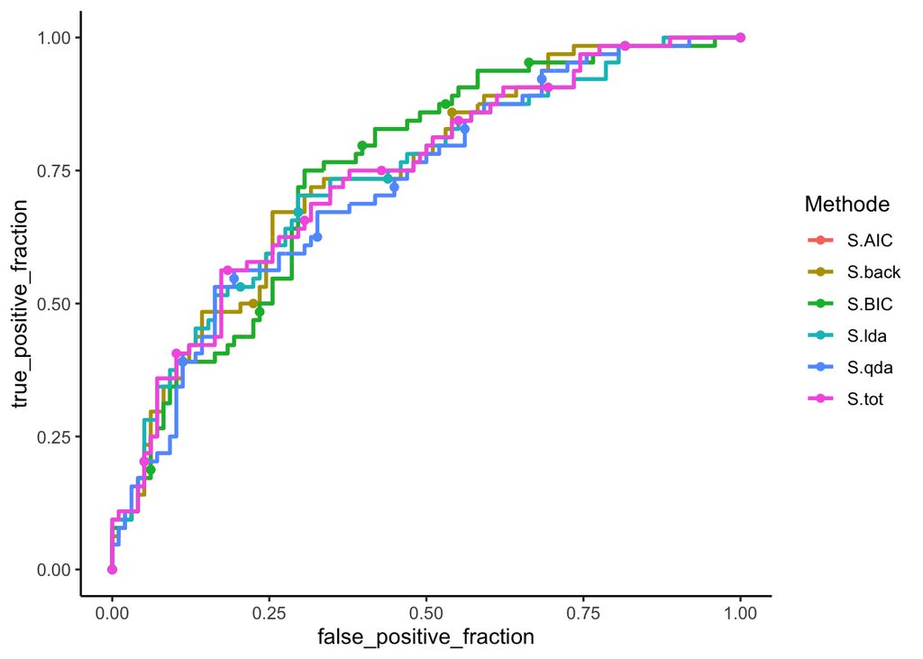

```r
score1 <- score %>% mutate(obs=dtest$chd) %>%
  gather(key="Methode",value="score",-obs)
library(plotROC)
ggplot(score1)+aes(d=obs,m=score,color=Methode)+geom_roc(labels=FALSE)
```

```r
score1 %>% group_by(Methode) %>%
  summarise(AUC=pROC::auc(obs,score)) %>% arrange(desc(AUC)) %>%
  mutate(AUC=round(AUC,3))
```

| Methode | AUC |
| --- | --- |
| S.AIC | 0.747 |
| S.BIC | 0.747 |
| S.back | 0.742 |
| S.tot | 0.739 |
| S.lda | 0.736 |
| S.qda | 0.721 |